# Producción científica del IVIC

José R. Ferrer Paris (@jrfep)

Febrero 25, 2019

El [Instituto Venezolano de Investigaciones Científicas](https://es.wikipedia.org/wiki/Instituto_Venezolano_de_Investigaciones_Cient%C3%ADficas) (IVIC) cumplió este mes 60 años. Mientras [las autoridades celebran](http://www.ivic.gob.ve/es/actualidad-6/galerias-60-aniversario), muchos investigadores [denuncian](http://talcualdigital.com/index.php/2019/02/14/60-anos-del-ivic-por-gioconda-cunto-de-san-blas/) y [documentan](http://efectococuyo.com/principales/ivic-cumple-60-anos-en-medio-de-una-crisis-que-desmembro-a-su-comunidad-cientifica/) el triste deterioro de una institución fundamental para la ciencia en Venezuela.

Me parece que cada aniversario es un momento oportuno para ver con un ojo crítico el pasado y el presente de la institución, y hacer un balance de logros, aciertos y desaciertos, y reflexionar sobre como reorientar las políticas futuras.

En ocasiones anteriores me he enfocado en la [memoria histórica](https://es.wikipedia.org/w/index.php?title=Instituto_Venezolano_de_Investigaciones_Cient%C3%ADficas&action=history) del instituto y en [analizar la formación de talento humano](https://doi.org/10.6084/m9.figshare.3394789.v4) del Centro de Estudios Avanzados. Aunque actualmente estoy alejado físicamente, espero que mis humildes aportes sean útiles para aquellos que pueden (o podrán) tomar decisiones para recuperar la capacidad científica nacional.

Hoy voy a contribuir con un par de líneas de código para mostrar como hacer un [análisis bibliométrico](https://es.wikipedia.org/wiki/Bibliometr%C3%ADa) de la producción científica del IVIC usando un par de herramientas libres.

## Explorando los datos

Para este análisis voy a descargar una lista de publicaciones que esté asociada con investigadores y laboratorios del IVIC y otros institutos y universidades venezolanas.

Para ello voy a utilizar la herramienta **[Crossref REST API](https://github.com/CrossRef/rest-api-doc)**. La base de datos de CrossRef es una herramienta de acceso libre para análisis bibliométricos. La interfase API permite acceder a esta base de datos utilizando intrucciones codificadas en una dirección en formato URL y obtener la respuesta en formato JSON. Estos datos los leemos directamente con el paquete **RJSONIO** para guardar los resultados en un objeto de R.

```r
require(RJSONIO)
if (!exists("qry.IVIC"))
   qry.IVIC <- fromJSON("http://api.crossref.org/works?query.affiliation=Instituto+Venezolano+Investigaciones+Cientificas+Caracas+Miranda+Venezuela&rows=1000")
```

En esta consulta la búsqueda por el campo de afiliación de los autores se hace con la expresión *works?query.affiliation=X*. El número máximo de trabajos que se pueden consultar son 1000. Estos resultados son ordenados por un algoritmo de relevancia por aproximación de las palabras claves, por tanto se espera que los primeros resultados de este conjunto se ajusten mejor a la búsqueda, pero también puede incluir algunos resultados pocos relevantes.

Por otro lado la búsqueda no se puede considerar exhaustiva, si no más bien representativa (o al menos eso esperamos). Por ejemplo en este caso no vamos a obtener todos los resultados que hayan sido publicados por investigadores del IVIC, sino una muestra de los trabajos de la base de datos que contengan esta información. Por tanto pueden haber sesgos por omisión de datos en la fuente (afiliación no reportada o errónea) o por falta de cobertura de algunas revistas o casas editoriales, etc. Es importante tomar esto en cuenta al comparar los resultados con otras herramientas bibliográficas más exhaustivas.

Continuando con este análisis, el objeto que guardamos tiene un formato de lista, y navegando por esta estructura se llega a una lista interna de *items*, cada *item* tiene una cantidad variable de nodos de información, incluyendo datos de revista, DOI, autores, etc.

```r
str(qry.IVIC,1)
```

```
## List of 4
##  $ status         : chr "ok"
##  $ message-type   : chr "work-list"
##  $ message-version: chr "1.0.0"
##  $ message        :List of 5
```

```r
str(qry.IVIC$message$items[[1]],1)
```

```
## List of 32
##  $ indexed               :List of 3
##  $ reference-count       : num 19
##  $ publisher             : chr "Ovid Technologies (Wolters Kluwer Health)"
##  $ issue                 : chr "4"
##  $ content-domain        :List of 2
##  $ short-container-title : chr "Arteriosclerosis"
##  $ published-print       :List of 1
##  $ DOI                   : chr "10.1161/01.atv.8.4.368"
##  $ type                  : chr "journal-article"
##  $ created               :List of 3
##  $ page                  : chr "368-377"
##  $ source                : chr "Crossref"
##  $ is-referenced-by-count: num 119
##  $ title                 : chr "Identification of Apo B-100 segments mediating the interaction of low density lipoproteins with arterial proteoglycans."
```

[output cut: 18 more lines]

Para minimizar algunos de los sesgos mencionados arriba, debemos revisar y verificar los resultados para filtrar aquellos resultados que nos interesan y descartar los dudosos o errados. Para ello vamos a hacer una tabla (o *data.frame*) con la lista de autores, y su respectiva afiliación para cada publicación. Utilizamos el DOI (“digital object identifier”) como código de identificación del documento.

En un primer paso, vamos a revisar donde está esta información. Tomamos por ejemplo uno de los items de la búsqueda y vemos la estructura de la lista de autores:

```r
w <- qry.IVIC$message$items[[252]]
str(w$author,2)
```

```
## List of 1
##  $ :List of 4
##   ..$ given      : chr "Hebe M. C."
##   ..$ family     : chr "Vessuri"
##   ..$ sequence   : chr "first"
##   ..$ affiliation:List of 1
```

```r
lista.autores <- data.frame()
for (k in 1:length(w$author)) {
    lista.autores <- rbind(lista.autores,
              data.frame(DOI=w$DOI,
            orig.given=iconv(w$author[[k]]$given,"latin1","utf8"),
            orig.family=iconv(w$author[[k]]$family,"latin1","utf8"),
            orig.affiliation=iconv(w$author[[k]]$affiliation[[1]],"latin1","utf8")))
}
lista.autores
```

```
##                                  DOI orig.given orig.family
## name 10.1590/s0104-59702001000400002 Hebe M. C.     Vessuri
##                                                     orig.affiliation
## name Instituto Venezolano de Investigaciones Científicas,  Venezuela
```

Añadimos una *loop* adicional para extraer la lista de varias referencias:

```r
for (ws in c(1,253,345,678,975)) {
w <- qry.IVIC$message$items[[ws]]
for (k in 1:length(w$author)) {
    lista.autores <- rbind(lista.autores,
              data.frame(DOI=w$DOI,
            orig.given=iconv(w$author[[k]]$given,"latin1","utf8"),
            orig.family=iconv(w$author[[k]]$family,"latin1","utf8"),
            orig.affiliation=iconv(w$author[[k]]$affiliation[[1]],"latin1","utf8")))
}
}
```

Y luego podemos usar las funciones *grepl* y *aggregate* para resumir el número de autores que incluyen la información deseada en su afiliación:

```r
rsm.autores <- with(lista.autores,
    aggregate(data.frame(IVIC=grepl("Instituto Venezolano de Investigaciones Científicas",orig.affiliation),
        vzla=grepl("Venezuela",orig.affiliation)),
        by=list(DOI=DOI),sum))
```

Por otro lado también queremos tener información básica sobre los artículos, por ejemplo:

```r
info.arts <- data.frame()
for (ws in c(1,252,253,345,678,975)) {
w <- qry.IVIC$message$items[[ws]]
    info.arts <- rbind(info.arts,
              data.frame(DOI=w$DOI,
          titulo=substr(iconv(w$title,"latin1","utf8"),1,50),
          citas=w$`is-referenced-by-count`))
}
```

Y podemos combinar ambas tablas:

```r
merge(info.arts,rsm.autores,by="DOI")
```

```
##                               DOI
## 1       10.1080/00103629009368236
## 2   10.1080/17518369.2018.1490619
## 3          10.1161/01.atv.8.4.368
## 4      10.1366/000370268774384010
## 5 10.1590/s0104-59702001000400002
## 6 10.1590/s1677-04202003000300004
##                                               titulo citas IVIC vzla
## 1 Chemical properties of soils where palm trees grow     3    0    4
## 2 Provenance, transport and diagenesis of sediment i     1    1    1
## 3 Identification of Apo B-100 segments mediating the   119    0    5
## 4 Quantitative Spectrographic Analysis of Gold on Co     0    0    1
## 5 Enfermería de salud pública, modernización y coope     2    1    1
## 6 The effect of lead on the phytochemistry of Tithon    14    1    1
```

Para poder hacer los análisis al nivel deseado, es necesario que repitamos varias búsquedas y re-escalemos el código para poder aplicar estos datos a todos los *items* descargados, y luego filtrarlos y validarlos hasta tener una base de datos robusta. Por ejemplo, si queremos comparar el desempeño del IVIC con la producción científica venezolana, debemos descargar un conjunto comparable de referencias para varias instituciones académicas. Las herramientas que hemos visto permiten hacer esto de una forma automática con muy pocas líneas de código (que no muestro aquí por motivos de espacio).

Con todos los filtros y pasos aplicados pasamos de una lista de 8000 resultados crudos a una selección de apenas 2315 con los cuales hacer los análisis en la siguiente sección.

## Análisis y resultados

Generalmente preparar los datos consume la mayor parte del tiempo, pero la parte interesante empieza con los análisis. Aquí vamos a probar con algunas medidas sencillas para tener una visión inicial de la producción científica del IVIC comparada con otras instituciones de Venezuela.

### Tasa de publicaciones anuales

Para cada artículo en nuestra lista tenemos la fecha de publicación, y podemos ver si la tasa de acumulación de artículos incrementa o se mantiene en el periodo registrado en la base de datos de CrossRef.

Hacemos una tabla que resuma el número de artículos acumulados por año:

```r
yr <- range(info.articulos$fecha)
dts <- data.frame()
for (ys in yr[1]:yr[2]) {
ss <- subset(info.articulos,fecha<=ys)

dts <- rbind(dts,data.frame(fecha=ys,n.articulos=nrow(ss),n.articulos.IVIC=sum(ss$IVIC>0)))
}
```

Hacemos un gráfico para visualizar la tendencia general de los últimos 60 años de producción científica en Venezuela:

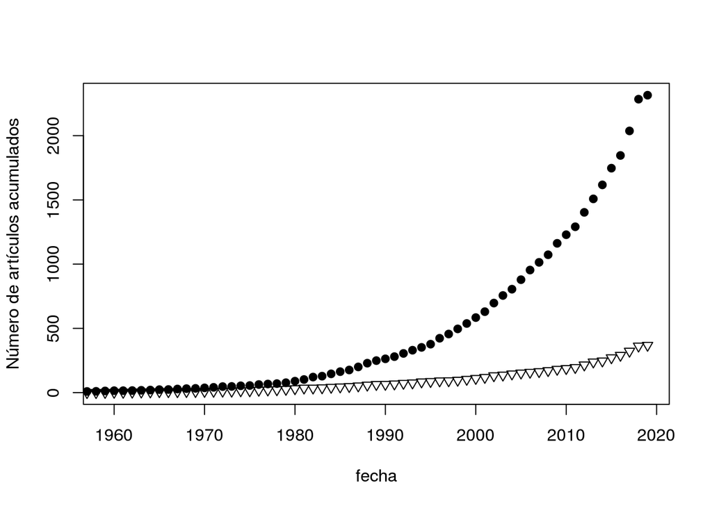

```r
plot(n.articulos~fecha,data=dts,xlim=c(1959,2019),pch=19,ylab="Número de artículos acumulados")
points(n.articulos.IVIC~fecha,data=dts,xlim=c(1959,2019),pch=6)
```

Esperamos que estas tendencias sean aproximadamente exponenciales, debido a que un aumento constante en las infraestructuras y capacidades científicas debería reflejarse en un aumento proporcional de la producción anual.

Sin embargo, el mismo gráfico en escala logarítmica muestra que no hay un incremento contínuo, sino que hay periodos de aceleración y desaceleración evidentes.

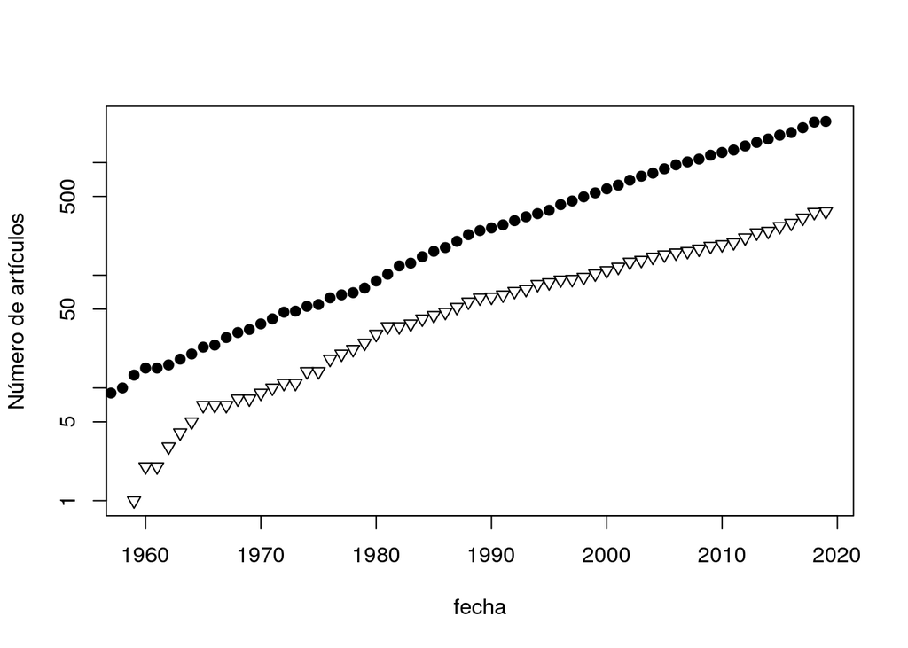

```r
plot(n.articulos~fecha,data=dts,xlim=c(1959,2019),pch=19,ylab="Número de artículos",log="y")
points(n.articulos.IVIC~fecha,data=dts,xlim=c(1959,2019),pch=6)
```

### Medidas de impacto: Número de citas por artículo

El número de citas es la medida más utilizada para medir el impacto de la producción científica. Si, todo el que ha estado involucrado en este tema ha pasado por esos ciclos recurrentes de discusión sobre la importancia y relevancia de las citas, sus pro y sus contras, la necesidad de buscar otros indicadores, etc. Pero al final, siempre terminan siendo parte del cálculo.

En nuestra colección de artículos tenemos un total de citas de:

```r
## todos los de Venezuela
sum(info.articulos$citas)
```

```
## [1] 14622
```

```r
## publicaciones del IVIC
sum(subset(info.articulos,IVIC>0)$citas)
```

```
## [1] 2562
```

O sea el número promedio de citas por artículo es:

```r
 ## para toda Venezuela
mean(info.articulos$citas)
```

```
## [1] 6.316199
```

```r
## publicaciones del IVIC
mean(subset(info.articulos,IVIC>0)$citas)
```

```
## [1] 6.961957
```

Lo cual parece indicar que las publicaciones del IVIC generalmente tienen un mayor impacto que el promedio de Venezuela

Sin embargo este valor es poco informativo. Generalmente la distribución de citas en un conjunto de artículos tiene una distribución muy desigual y apenas se aprecian los valores extremos:

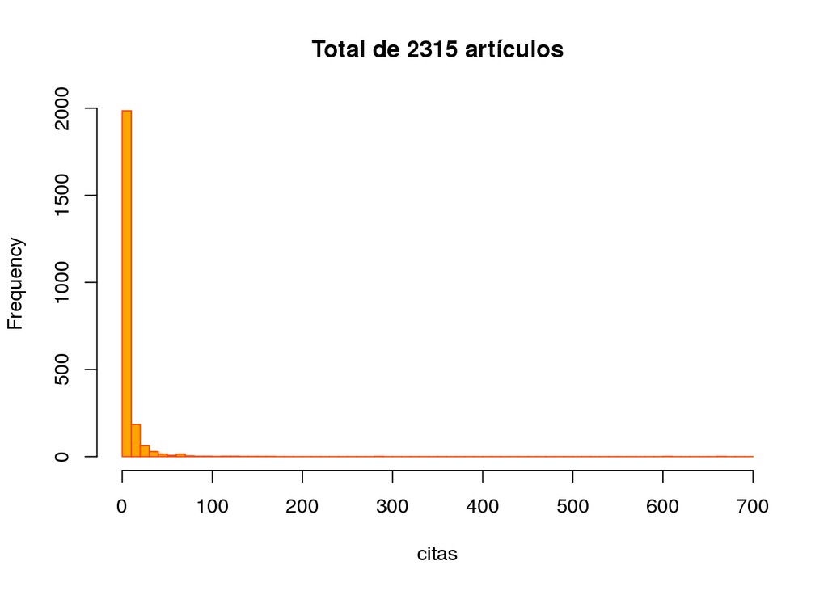

```r
hist(info.articulos$citas,border="orangered",col="orange",
breaks=seq(0,700,by=10),
xlab="citas",main=sprintf("Total de %s artículos",nrow(info.articulos)))
```

Esto quiere decir que la mayoría de los artículos tienen un impacto muy pequeño en el total de citas del conjunto. Vemos que por ejemplo la media y el promedio tienen valores muy diferentes, y ofrecen diferentes interpretaciones:

```r
 ## para toda Venezuela
summary(info.articulos$citas)
```

```
##    Min. 1st Qu.  Median    Mean 3rd Qu.    Max.
##   0.000   0.000   1.000   6.316   6.000 668.000
```

```r
## publicaciones del IVIC
summary(subset(info.articulos,IVIC>0)$citas)
```

```
##    Min. 1st Qu.  Median    Mean 3rd Qu.    Max.
##   0.000   0.000   2.000   6.962   7.000 119.000
```

Por otro lado estamos comparando un subconjunto de datos con el total, y no sabemos si existe una diferencia significativa entre ellos. Recordemos que los artículos del IVIC representan el 15.9 del conjunto total.

Por eso utilizo un método de *[rarefacción](https://es.wikipedia.org/wiki/Rarefacci%C3%B3n)* y *[regresión de cuantíles](https://en.wikipedia.org/wiki/Quantile_regression) para comprobar si el valor observado para el IVIC es efectivamente mejor de lo que esperariamos para una muestra aleatoria del total de artículos. Para ello cargo el paquete* quantreg* de *R*.

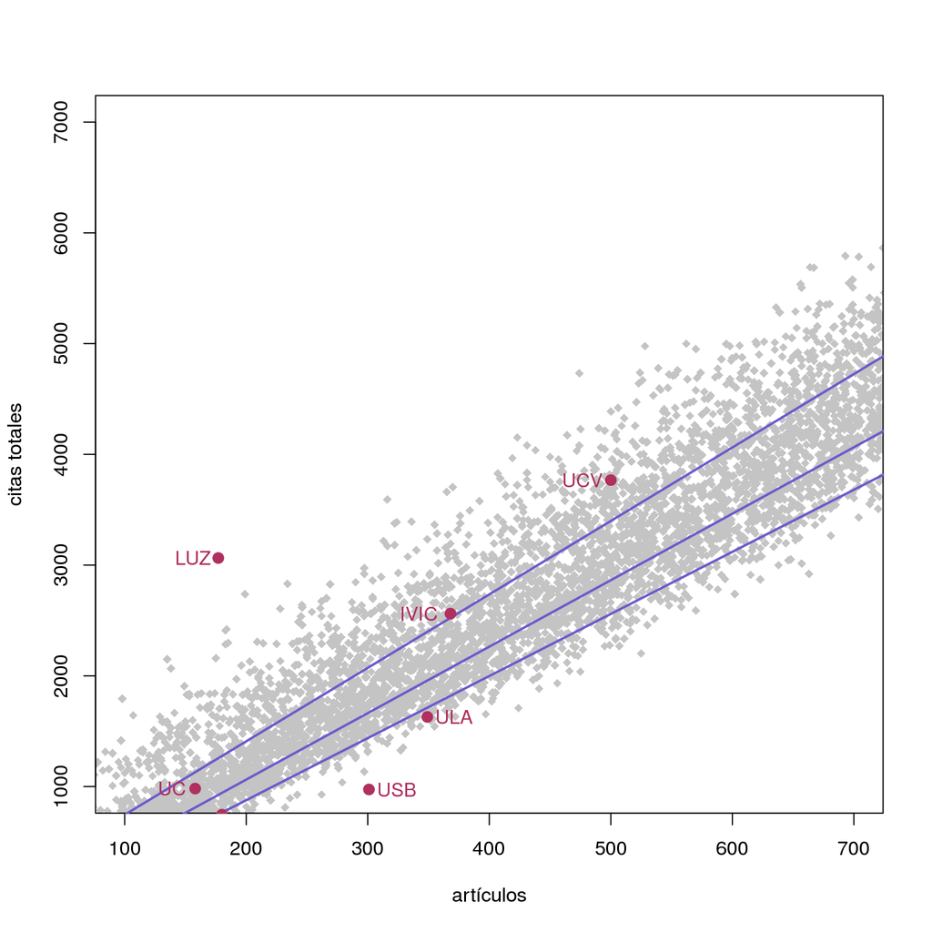

```r
require(quantreg)

t0 <- c()
ns <- c()
for (k in 1:10000) {
    n <- round(runif(1,0,1200))
    h <- sum(sample(info.articulos$citas,n))
    if (length(h)==1) {
        ns <- c(ns,n)
        t0 <- c(t0,h)
    }
    }

plot(ns,t0,col="grey77",pch=18,xlab="artículos",
    xlim=c(100,700),ylim=c(1000,7000),
    ylab="citas totales")
taus <- c(.25,.05,.75)
  xx <- 1:1200
     f <- coef(rq(t0~ns,tau=taus))
     yy <- cbind(1,xx)%*%f

lines(xx,yy[,1],col = "slateblue",lty=1,lwd=2)
lines(xx,yy[,2],col = "slateblue",lty=1,lwd=2)
lines(xx,yy[,3],col = "slateblue",lty=1,lwd=2)

ss <- subset(info.articulos,IVIC>0)
points(nrow(ss),sum(ss$citas),pch=19,cex=1.2,col="maroon")
text(nrow(ss),sum(ss$citas),"IVIC",col="maroon",adj=1.35)

ss <- subset(info.articulos,UDO>0)
points(nrow(ss),sum(ss$citas),pch=19,cex=1.2,col="maroon")
text(nrow(ss),sum(ss$citas),"UDO",col="maroon",adj=c(1.1,1.1))

ss <- subset(info.articulos,ULA>0)
points(nrow(ss),sum(ss$citas),pch=19,cex=1.2,col="maroon")
text(nrow(ss),sum(ss$citas),"ULA",col="maroon",adj=-.2)

ss <- subset(info.articulos,UCV>0)
points(nrow(ss),sum(ss$citas),pch=19,cex=1.2,col="maroon")
text(nrow(ss),sum(ss$citas),"UCV",col="maroon",adj=1.2)

ss <- subset(info.articulos,UC>0)
points(nrow(ss),sum(ss$citas),pch=19,cex=1.2,col="maroon")
text(nrow(ss),sum(ss$citas),"UC",col="maroon",adj=1.35)

ss <- subset(info.articulos,LUZ>0)
points(nrow(ss),sum(ss$citas),pch=19,cex=1.2,col="maroon")
text(nrow(ss),sum(ss$citas),"LUZ",col="maroon",adj=1.2)

ss <- subset(info.articulos,USB>0)
points(nrow(ss),sum(ss$citas),pch=19,cex=1.2,col="maroon")
text(nrow(ss),sum(ss$citas),"USB",col="maroon",adj=-.2)
```

Efectivamente en este caso el IVIC aparece en el campo superior, acompañado de dos instituciones que en teoría tienen una planta profesional y académica mucho mayor.

### Medidas de impacto: índice h o índice de Hirsch

En el gráfico anterior vemos que sobresale [La Universidad del Zulia](http://www.luz.edu.ve/) con pocos artículos pero muchas citas. En parte este resultado puede explicarse por la inclusión del artículo *[Global Prevalence of Autism and Other Pervasive Developmental Disorders](https://dx.doi.org/10.1002/aur.239)* con un considerable número de [citas reportadas](https://badge.dimensions.ai/details/doi/10.1002/aur.239).

El índice h o [índice de Hirsch](https://en.wikipedia.org/wiki/H-index) es usado comunmente como una medida de impacto que reduce el sesgo por la distribución de valores extremos en una colección de artículos. El valor h indica que *h* artículos tienen *h* o más citas, y lo podemos calcular con la siguiente función en R:

```r
Hindex <- function(x) {
 xs <- sort(unique(x))
 ys <- c()
 for (k in xs) {
  ys <- c(ys,sum(x>=k))
 }
return(xs[which.min(ifelse(ys>xs,ys-xs,NA))])
}
```

Para nuestra colección tenemos los siguientes valores:

```r
## para toda la colección
Hindex(info.articulos$citas)
```

```
## [1] 46
```

```r
## para las publicaciones del IVIC
Hindex(subset(info.articulos,IVIC>0)$citas)
```

```
## [1] 22
```

Pero al igual que con el valor de citas totales, debemos considerar las diferencias de tamaño muestral. Con este código aplicamos nuevamente el principio de rarefacción para el caso del índice h, y vemos como se desempeñan las instituciones en comparación con el gradiente esperado en una muestra aleatoria.

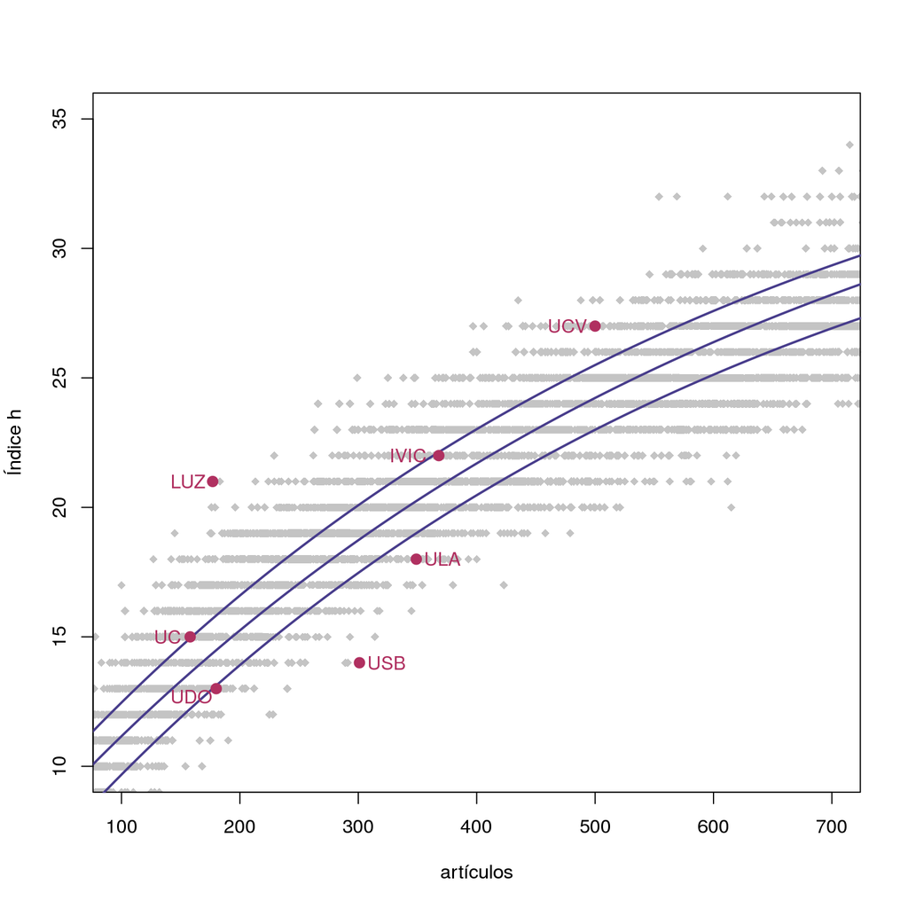

```r
h0 <- c()
ns <- c()
for (k in 1:10000) {
    n <- round(runif(1,0,1200))
    h <- Hindex(sample(info.articulos$citas,n))
    if (length(h)==1) {
        ns <- c(ns,n)
        h0 <- c(h0,h)
    }
    }

plot(ns,h0,col="grey77",pch=18,xlab="artículos",
    xlim=c(100,700),ylim=c(10,35),
    ylab="Índice h")
mdl2 <- nlrq(h0 ~ SSasymp(ns, Asym, RO, lrc), tau=0.5)
lines(1:1200,predict(mdl2,newdata=data.frame(ns=1:1200)),lty=1,lwd=2,col="slateblue4")

mdl3 <- nlrq(h0 ~ SSasymp(ns, Asym, RO, lrc), tau=0.25)
lines(1:1200,predict(mdl3,newdata=data.frame(ns=1:1200)),lty=1,lwd=2,col="slateblue4")
mdl4 <- nlrq(h0 ~ SSasymp(ns, Asym, RO, lrc), tau=0.75)
lines(1:1200,predict(mdl4,newdata=data.frame(ns=1:1200)),lty=1,lwd=2,col="slateblue4")

ss <- subset(info.articulos,USB>0)
points(nrow(ss),Hindex(ss$citas),pch=19,cex=1.2,col="maroon")
text(nrow(ss),Hindex(ss$citas),"USB",col="maroon",adj=-.2)


ss <- subset(info.articulos,IVIC>0)
points(nrow(ss),Hindex(ss$citas),pch=19,cex=1.2,col="maroon")
text(nrow(ss),Hindex(ss$citas),"IVIC",col="maroon",adj=1.35)

ss <- subset(info.articulos,UDO>0)
points(nrow(ss),Hindex(ss$citas),pch=19,cex=1.2,col="maroon")
text(nrow(ss),Hindex(ss$citas),"UDO",col="maroon",adj=c(1.1,1.1))

ss <- subset(info.articulos,ULA>0)
points(nrow(ss),Hindex(ss$citas),pch=19,cex=1.2,col="maroon")
text(nrow(ss),Hindex(ss$citas),"ULA",col="maroon",adj=-.2)

ss <- subset(info.articulos,UCV>0)
points(nrow(ss),Hindex(ss$citas),pch=19,cex=1.2,col="maroon")
text(nrow(ss),Hindex(ss$citas),"UCV",col="maroon",adj=1.2)

ss <- subset(info.articulos,UC>0)
points(nrow(ss),Hindex(ss$citas),pch=19,cex=1.2,col="maroon")
text(nrow(ss),Hindex(ss$citas),"UC",col="maroon",adj=1.35)

ss <- subset(info.articulos,LUZ>0)
points(nrow(ss),Hindex(ss$citas),pch=19,cex=1.2,col="maroon")
text(nrow(ss),Hindex(ss$citas),"LUZ",col="maroon",adj=1.2)
```

Para este indicador, el IVIC se encuentra en un campo de desempeño “alto”, pero no tanto como otras instituciones.

## Listo por hoy

Con estos resultados se muestra que la producción científica del IVIC no mantiene una tasa de producción constante en estos 60 años de vida, y se compara su desempeño con el de otras instituciones científicas en Venezuela usando dos indicadores de impacto basados en las citas bibliográficas.

Este análisis es una breve introducción a este tema que espero seguir desarrollando en futuras contribuciones.